# What Can NMR Teach Us About Quantum Computing?

NMR and Quantum Computing

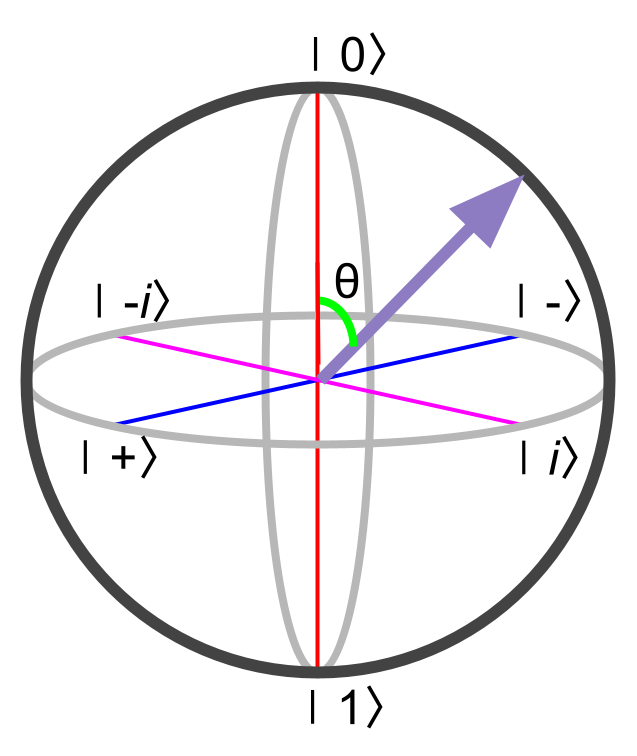

## *Expected Learning Outcomes*

*At the end of this module, students should be able to…*

1. *Provide key differences between classical and quantum computing*
2. *Use their understanding of spin dynamics on the Bloch sphere to find NMR analogues for single-qubit quantum gates*
3. *Interpret quantum circuit diagrams and accurately predict the probability of different outputs for given inputs*

> **“The history of the universe is, in effect, a huge and ongoing quantum computation. The universe is a quantum computer.”**

# Quantum Information Science and Technology

**quantum information science and technology** - a field that draws from information theory, computer science, and quantum mechanics to process information in fundamentally new ways ([1](https://qis-learners.research.illinois.edu/about/)).

**quantum computer** - a computer that harnesses the quantum behavior of light and matter to provide a radically different and fundamentally more powerful way of computing ([2](https://uwaterloo.ca/institute-for-quantum-computing/resources/quantum-101/glossary)).

**entanglement** - quantum phenomenon where the measurement outcomes of two quantum objects are so strongly correlated that their quantum states are inherently intertwined and cannot be distinguished from the eachother.

The discovery and development of quantum mechanics throughout the 20th century led to some of the biggest technological advances made by humans, including laser systems, fusion reactors, MRI machines, and the fundamental components of computers - transistors and semiconductor devices. Naturally, physicists would like to further extend their understanding of the quantum realm to build even more powerful computing devices. A rapidly growing multidisciplinary field brings together physicists, computer scientists, chemists, engineers, and more - **quantum information science and technology**.

The foundational tool of quantum information science is the **quantum computer** - a computer that harnesses the quantum behavior of light and matter to provide a radically different and fundamentally more powerful way of computing ([2](https://uwaterloo.ca/institute-for-quantum-computing/resources/quantum-101/glossary)). Quantum phenomena such as quantum superposition and **entanglement** are the primary drivers of the potentially exponential boost in processing power that quantum computers could theoretically provide. The 2022 Nobel Prize in Physics was awarded to Alain Aspect, John Clauser, and Anton Zeilinger for their pioneering experiments exploring entanglement and providing a foundation for quantum computing.

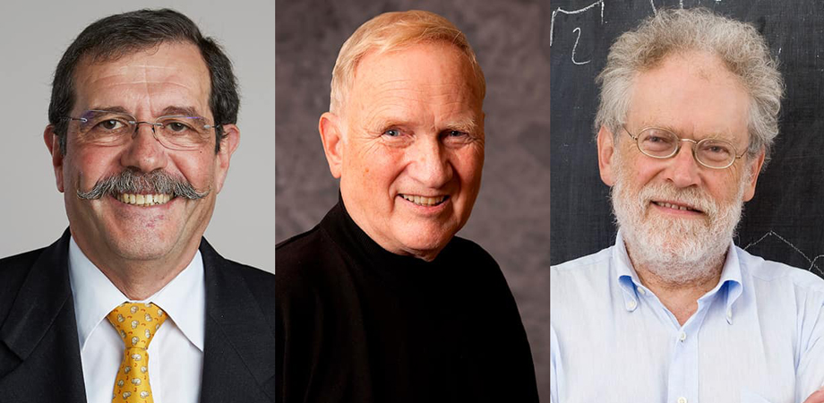

Photos of Alain Aspect, John Clauser, and Anton Zeilinger. CC BY-SA Royal Society; CC BY-SA John Clauser; CC BY-SA Austrian Academy of Sciences.

“This is richly deserved because these are the pioneers of modern quantum physics. Their experiments confirmed the most bizarre and possibly most important aspect of quantum theory – entanglement.” - Jeff Forshaw, particle physicist at the University of Manchester ([3](https://spie.org/news/weirdness-and-wonder-quantum-entanglement-work-wins-2022-nobel-prize-for-physics?SSO=1))

Along with the huge boost in computing power which can potentially solve some computationally-intensive problems much faster than conventional ‘classical’ computers, some of the most exciting potential applications of quantum computing include:

- *quantum cryptography* - securely sending information using quantum physics principles so that it would be impossible to eavesdrop undetected,
- *quantum sensing* - using qubits as sensors that could measure physical properties with the highest precision allowed by quantum mechanics,
- *quantum simulation* - using a quantum computer to simulate quantum systems enabling scientists to design new drugs and materials with specific properties.

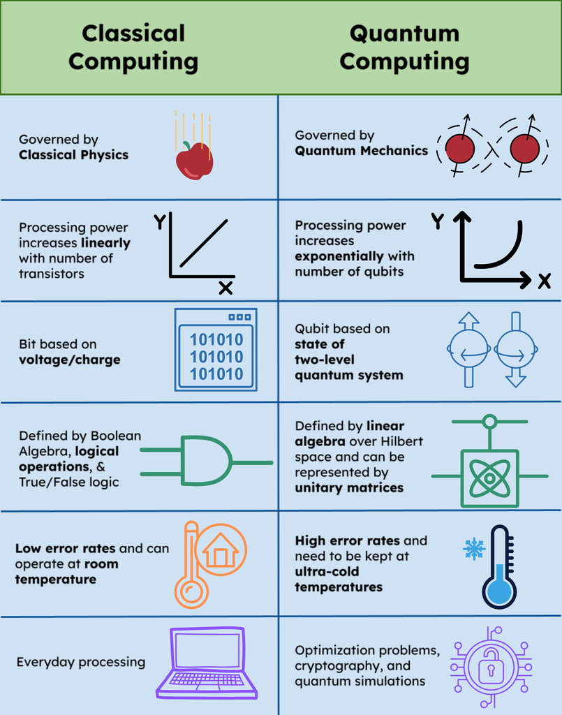

In this module, we will learn about some of the basics of quantum computing using the NMR knowledge you have already acquired in previous modules. You may be surprised how much you know already, once you learn the quantum computation lingo.

## Classwide Discussion

- Using examples from the information presented above, why do you think there is increased interest in developing quantum computers?
- What scientific fields, industries, and professions have the most to gain from quantum computing?
- What are likely the biggest challenges in developing large-scale quantum computers?

# Qubits and the Bloch Sphere

**bit** - a binary digit, the basic unit of information in classical computing; the two possible states of a bit are often represented by 0 and 1.

**qubit** - a quantum bit, the basic unit of information in quantum computing; the possible states of a qubit are often represented by the Bloch sphere.

In classical computers (i.e., the desktops, laptops, and smartphones you likely use every day), the computations are done using binary digits called **bits**. The bit is a basic unit of information in computing and each bit can only be in one of two possible states, 0 or 1. In quantum computers, these bits are called quantum bits or **qubits**. Qubits use the quantum mechanical phenomena of superposition to achieve any linear combination of the two quantum states, $|0〉$ or $|1〉$. Qubits are made from simple two-level systems, like the spin-1/2 systems we have been exploring, and are typically represented by a Bloch sphere. A comparison of the spin-1/2 Bloch sphere and the qubit Bloch sphere showing commonly used qubit states in quantum computing is shown below.

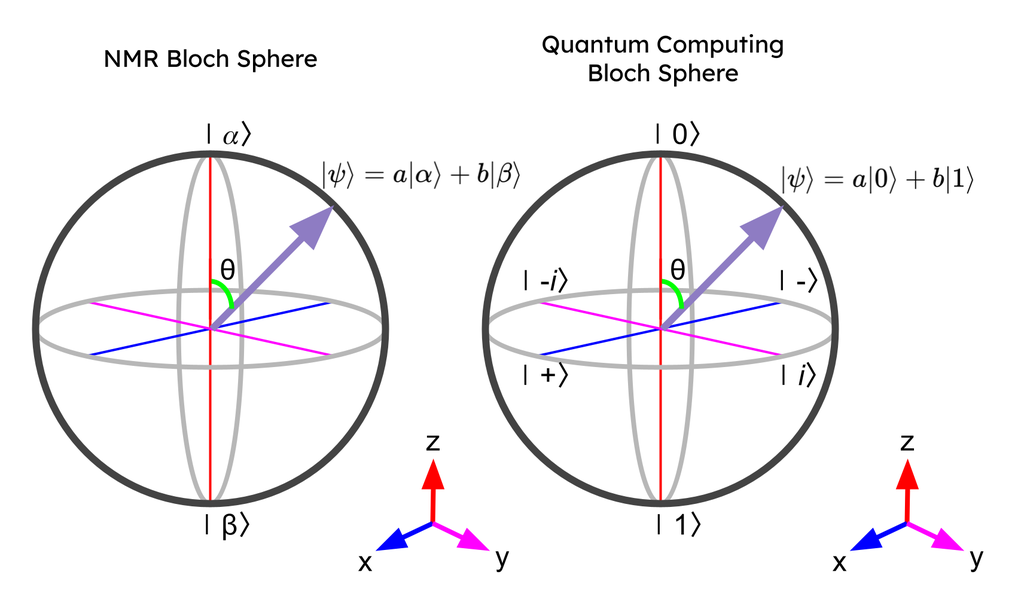

## Superposition States

**superposition state** - a quantum state that is a combination of multiple distinct stationary states and is represented as a linear combination of those stationary states.

A reminder that the only state a qubit can be measured in are the $|0〉$ or $|1〉$ states. If the state vector, $|\psi〉$ (represented by the purple arrow), points to any other point along the Bloch sphere that is *not* the two poles, then it is in a **superposition state** that can be written as a linear combination of the $|0〉$ or $|1〉$ states, e.g.
$$|\psi〉= a |0〉+ b |1〉.$$
$a$ and $b$ are complex numbers where the norm (or magnitude) of the state vector, $||\psi||$ is always 1, e.g.
$$||\psi||= |a|^2 + |b|^2 = 1.$$

The probability that the qubit will be measured in the $|0\rangle$ state is given by $|a|^2$ and the $|1〉$ state is given by $|b|^2$. If you know the polar angle, $\theta$, between $|\psi\rangle$ and $|0\rangle$, then
$$|a|^2 = \cos^2(\theta/2) \quad \textrm{and} \quad |b|^2 = \sin^2(\theta/2).$$

Even if you do not know exactly what $\theta$ is, you can determine what state the qubit is most likely to be measured in by looking at the position of the state vector on the Bloch sphere. In general, the closer the state vector is to pointing directly at the pole, the higher the probability of measuring the qubit in that state.

## Guided Inquiry Questions

1. Looking at the two Bloch spheres above, which of the six qubit states ($|0〉$, $|1〉$, $|{+i}\rangle$, $|{-i}\rangle$, $|+〉$, and $|-〉$) correspond to the spin-up ($|\alpha〉$) and spin-down ($|\beta〉$) states in the spin-½ Bloch sphere? What do the remaining qubit states correspond to in the spin-½ Bloch sphere?
2. If the qubit were in one of the following qubit states, what would be the probability of measuring the qubit in the $|0\rangle$ state?
> 1. $|0〉$
> 2. $|1〉$
> 3. $|{+i}\rangle$
> 4. $|{-i}\rangle$
> 5. $|+〉$
> 6. $|-〉$
3. If spin-½ particles were to be used for qubits, what spin-½ state would you use for the qubit initialization state, $|0〉$?
4. If spin-½ particles were to be used for qubits, and all qubits were initialized in the quantum state $|0〉$, list the pulses (e.g. $90_X$, $180_Y$) you could use to get a qubit in the following states:
> 1. $|1〉$
> 2. $|{-i}〉$
> 3. $|+〉$
5. Why do you think what you have learned thus far about NMR may be useful in understanding how to control, store, and recall information from qubits?

# Quantum Circuits and Single-Qubit Quantum Gates

**quantum circuit model** - model of computation in which the qubits will undergo a series of operations from left to right, with each specific operation represented by a particular quantum gate

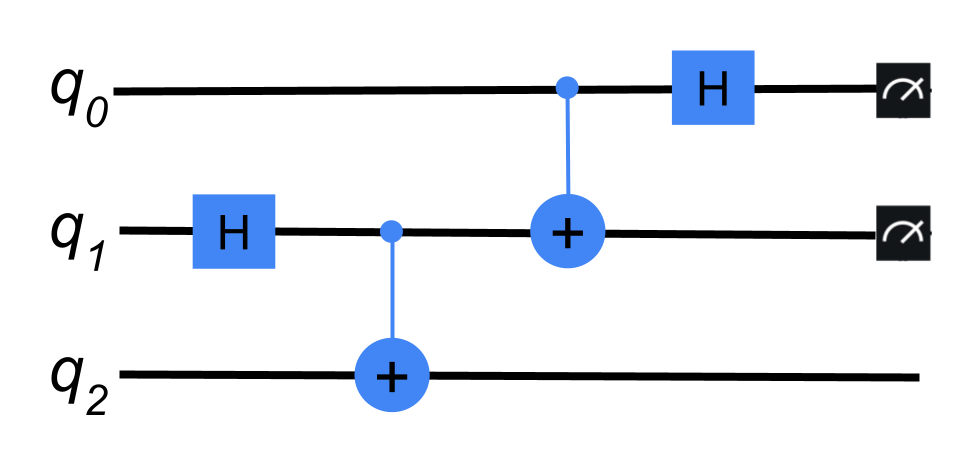

Figure above is an example a quantum circuit model for three qubits, $q_0$,$q_1$ and $q_2$ using Hadamard (H) and controlled-NOT gates. Qubits $q_0$ and $q_1$ are then measured and read-out at the end of the sequence.

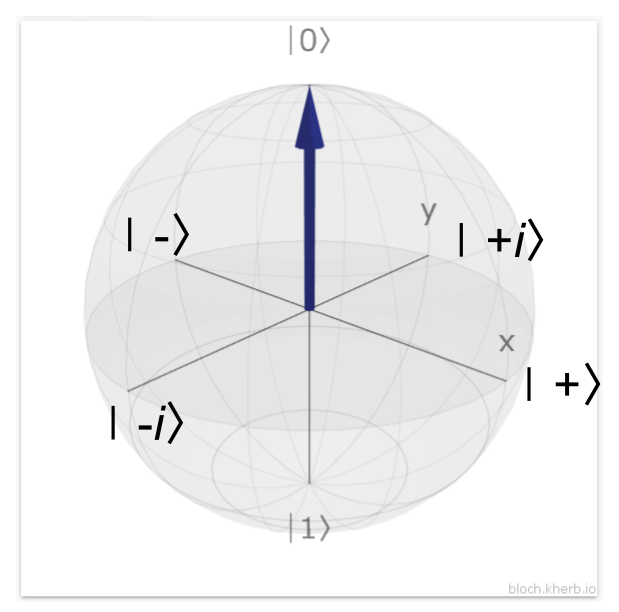

Open up [this Bloch sphere simulator](https://bloch.kherb.io/) . The Bloch sphere as shown in the simulator but with explicit labels for all six qubits states is provided in the margin for your reference. The quantum state starts in its initialized state and can be returned to this state using the INIT button in the upper left corner. You can also undo any previous command using the UNDO button also in the upper left. Take some time rotating the state around various axes of the Bloch sphere using the buttons in the right menu under ‘Rotations around default axes’. (What NMR pulses do these buttons correspond with?) Make sure you can accurately predict where the quantum state will end up if you click particular buttons. *Only continue on once you feel confident you know how these buttons will change the quantum state!*

Now click on the ‘Quantum gates’ heading in the right menu. Your goal is to determine what NMR pulses correspond to the three Pauli gates (X, Y, Z) and the Hadamard (H) gate. These are some of the most important single qubit gates used in quantum algorithms!

## Guided Inquiry Questions

6. Fill in the table below using the [Bloch sphere simulator.](https://bloch.kherb.io/)

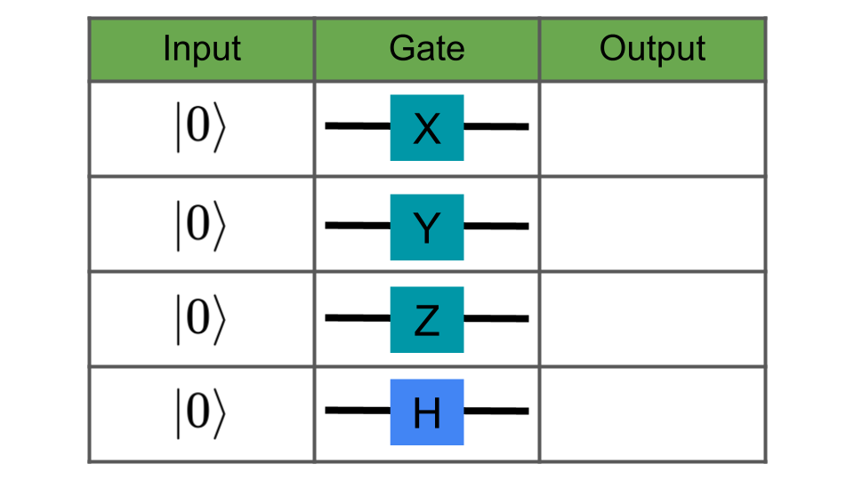

7. Notice the path the qubit’s state vector (the blue arrow in the simulator) takes when operated on by the various gates. If you were using a spin-1/2 particle as a qubit, what pulses could you use to mimic the following gates:
> 1. X
> 2. Y
> 3. Z
> 4. H (This is trickier than the others - look carefully at what axis the state vector is being rotated around!)
8. Using your NMR pulse analogues for the Pauli and Hadamard gates found in question 7, what outputs would you predict if the inputs in the table for question 6 were $|1\rangle$ instead of $|0\rangle$. Check your answer using the simulator. *Note: For checking your answer in the simulator, you need to now start the qubit in $|1\rangle$, so consider what gate/s you can first apply to get the qubit into $|1\rangle$ from its initialized state.*
9. In your opinion, why might the Hadamard gate be particularly useful for quantum computations?
10. Using your NMR pulse analogues for the Pauli and Hadamard gates found in question 7, what would be the output for the quantum circuit model below if the qubit is initialized in $|0\rangle$? Check your answer using the simulator.

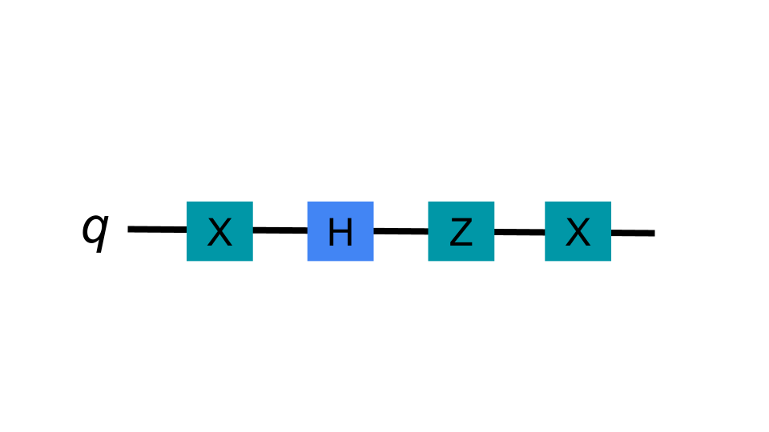

# Multiple Qubits

Most of the impressive computing power from quantum computing comes from the fact that qubits can be entangled with one another. That means we need a way to denote the state of a quantum system made up of multiple qubits and have quantum gates that can entangle qubits together. For an introduction, we will focus on two-qubit systems, but the concepts below can also be generalized to multiple-qubit systems.

## Two-Qubit States and Entangled States

Consider a system of two qubits, $q_1$ and $q_2$. We saw above that the general quantum state of a single qubit would be a linear combination of the *two* possible states that can occur when the qubit is measured, $|0\rangle$ and $|1\rangle$ states. Similarly, the general state of the two-qubit system can be written as a linear combination of the *four* different possible states that can occur when *both* qubits are measured:
$$|\Psi\rangle = a_{00}|00\rangle + a_{01}|01\rangle + a_{10}|10\rangle + a_{11}|11\rangle.$$
Here the first number within the ket is the measured value of $q_1$ and the second number is the measured value of $q_2$. For example, if $q_1$ were in $|0>$ and $q_2$ were in $|1>$, then the two-qubit state would be $|\psi\rangle = |01\rangle$. Also like the single qubit state, $a_{00}$, $a_{01}$ , $a_{10}$, and $a_{11}$ are complex numbers where the norm (or magnitude) of the state vector, $||\psi||$ is always 1, e.g.
$$||\psi||= |a_{00}|^2 + |a_{01}|^2 + |a_{10}|^2 + |a_{11}|^2= 1.$$
For example, the probability that $q_1$ will be measured in the $|0\rangle$ state and $q_2$ will be measured in the $|1\rangle$ state will be given by $|a_{01}|^2$.

Some of the most famous two-qubit states are the ‘maximally entangled’ Bell states, listed below:
$$|\Phi^+\rangle = \frac{1}{\sqrt{2}} |00\rangle + \frac{1}{\sqrt{2}} |11\rangle,\\
|\Phi^-\rangle = \frac{1}{\sqrt{2}} |00\rangle - \frac{1}{\sqrt{2}} |11\rangle,\\
|\Psi^+\rangle = \frac{1}{\sqrt{2}} |01\rangle + \frac{1}{\sqrt{2}} |10\rangle,\\
|\Psi^+\rangle = \frac{1}{\sqrt{2}} |01\rangle - \frac{1}{\sqrt{2}} |10\rangle.$$

We will explore in the questions below what makes these states different from other two-qubit states, which also hints at some of the interesting properties of entangled states.

## Guided Inquiry Questions

11. Suppose a two-qubit state is in the state:
    $$|\psi\rangle = \frac{1}{\sqrt{4}} |00\rangle + \frac{1}{\sqrt{4}} |01\rangle + \frac{1}{\sqrt{4}} |10\rangle + \frac{1}{\sqrt{4}} |11\rangle.$$
    What is the probability of measuring $|\psi\rangle$ in the following two-qubit states:
> 1. $|00\rangle$
> 2. $|01\rangle$
> 3. $|10\rangle$
> 4. $|11\rangle$
12. Suppose a two-qubit state is in the state $|\psi\rangle$ given in Question 11.
> 1. If you were to measure just $q_1$, what is the probability you would measure it to be in the state $|0\rangle$? $|1\rangle$?
> 2. If you now measured qubit 1 to be in the state $|0\rangle$, what is the probability that you would measure $q_2$ in the state $|0\rangle$?
13. Suppose a two-qubit state is in the Bell state, $|\Phi^+\rangle$. What is the probability of measuring the two-qubit system in the following states:
> 1. $|00\rangle$
> 2. $|01\rangle$
> 3. $|10\rangle$
> 4. $|11\rangle$
14. Suppose a two-qubit state is in the Bell state, $|\Phi^+\rangle$ as in Question 13.
> 1. If you were to measure just $q_1$, what is the probability you would measure it to be in the state $|0\rangle$? $|1\rangle$?
> 2. If you now measured qubit 1 to be in the state $|0\rangle$, what is the probability that you would measure $q_2$ in the state $|0\rangle$?

## Entangled States and Spooky Action

Maximally entangled states (like Bell states) have the unique property that measuring just one of the qubits provides you with information about the state of the other qubit as well. For example, compare your answers for Questions 12(b) and 14(b) above. If you were a particularly lazy experimenter who did not want to have to measure *both* qubits to determine their states, you would obviously prefer the qubits be in a maximally entangled Bell state, then you only need to measure one of them to know what both qubit states are.

This may not appear to be a big deal, but these types of states greatly bothered physicists like Einstein. Suppose you had your two qubits in a Bell state, and then you put one of your qubits on a space ship to Mars. As soon as the experimenter on Earth measures their qubit, then its as if the other other qubit on Mars instantaneously snaps into the matching state, before any signal from Earth (even traveling at the speed of light) could get to Mars. This type of ‘nonlocal’ interaction between entangled particles was termed “spooky action at a distance” by Einstein but was later proven by John Bell to be an essential part of quantum mechanics.

## Two-Qubit Quantum Gates and Entangled States

**Controlled-NOT or CNOT gate** - the state of the *target* qubit (denoted by the circle with a plus sign in the circuit model) depends on the state of the *control* qubit (denoted by the solid circle in the circuit model)

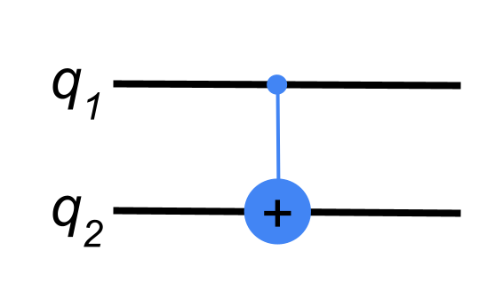

One of the most important two-qubit gates in quantum computing is the **controlled-NOT or CNOT gate**, represented by the diagram shown in the margin. The CNOT gate will change the state of the *target* qubit (denoted by the circle with a plus sign in the circuit model) depending on the state of the *control* qubit (denoted by the solid circle in the circuit model). The logic table for the CNOT gate is shown in the margin.

Below we will explore how the CNOT gate may be useful for entangling two qubits.

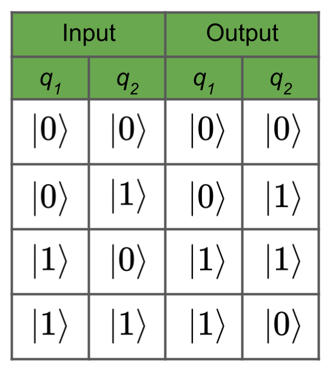

## Guided Inquiry Questions

15. In your own words, use the logic table for the CNOT gate above to explain what the CNOT gate does.
16. If the control qubit is in a state such as $|+\rangle$ and the target qubit is in $|0\rangle$, what can you say about the output state of the target qubit after being operated on by the CNOT gate? Would this be an entangled state for the two-qubit system?
17. Determine the final state of the following circuit if $q_1$ and $q_2$ are both initially set to $|0\rangle$. Anything special about this final state?

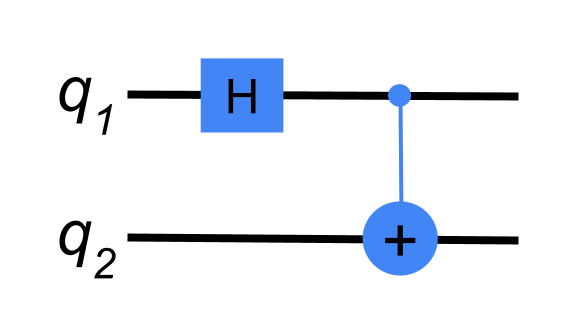

## Coupling and Entangling Spins

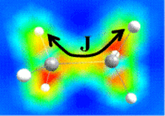

Figure courtesy of Allen D. Elster, MRIquestions.com

**J-coupling** - an indirect interaction where the magnetic moment of a nuclear spin in a molecule interacts with the electric field of nearby electrons, which then interacts with the magnetic moments of other nuclear spins in the molecule.

As we have seen, if our qubits are spin-1/2 particles, pulse sequences can act as single qubit gates. But what about multi-qubit gates and entanglement? In order to entangle multiple spins together, you need an interaction or coupling between the two spins. As we know, spins interact with magnetic fields and have their own magnetic dipole moments, so magnetic interactions of different types between spins are already present. However, if spins are moving around freely (as in a liquid) these dipolar interactions typically average out to near zero. Often the only remaining interaction between spins is called **J-coupling**. This indirect coupling between nuclear spins in a molecule is mediated by the bonded electrons, and so its strength is correlated with how many bond lengths away the targeted nuclei are from each other.

In order to replicate something like a CNOT gate using spins, we can use pulse sequences that purposely include free relaxation time where the targeted nuclei are primarily interacting indirectly via J-coupling. In fact, the use of pulse sequences and J-coupling enables a universal set of quantum gates that can be used for quantum computing.

# Making Quantum Computing a Reality

**Shor’s quantum factoring algorithm** - one of the most famous quantum algorithms that would have a significant speedup compared to classical algorithms; this algorithm efficiently finds the prime factors of any integer and could potentially break many current classical encryption systems

For good reason, NMR technology was a practical choice for the first experimental realizations of quantum computations. Magnetic resonance still provides the best techniques to control and harness quantum spins. An NMR quantum computer was the first to factor an integer using **Shor’s quantum factoring algorithm** in 2001. This NMR computer used a molecule with seven spin-1/2 nuclei as qubits, and although the integer they factored was 15, it was a proof of principle that quantum computing algorithms could be implemented in physical systems.

L.M.K. Vandersypen et. al., [Experimental realization of Shor’s quantum factoring algorithm using nuclear magnetic resonance](https://arxiv.org/abs/quant-ph/0112176), Nature Vol. 414, Dec. 2001

**quantum supremacy** - the point at which a quantum computer can perform certain tasks significantly faster than the fastest classical supercomputers

In a desire to reach **quantum supremacy**, the main challenges facing developers of quantum computers include:

- quantum decoherence,
- quantum error correction, and
- scalability.

Researchers are tackling these challenges in various ways and have expanded to explore other quantum systems, like superconducting circuits, trapped ions, or topological systems.

Even if ultimately quantum computers take other forms than the NMR systems we have been exploring, NMR techniques provide a helpful way to visualize and understand the quantum circuits and algorithms that these future quantum computers will be utilizing.

## Guided Inquiry Questions

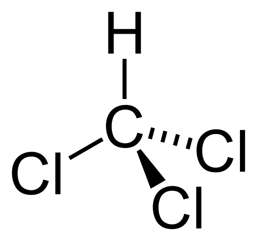

Original image by Benjah-bmm27, Vectorization: Fvasconcellos - converted by Fvasconcellos, Public Domain, https://commons.wikimedia.org/w/index.php?curid=1612305

For a simple 2-qubit NMR quantum computer, let’s consider using the molecule chloroform, shown in the margin.

18. Which two spin-1/2 nuclei in chloroform (and their isotopes) do you think would be good candidates for our two qubits?
19. How would you initialize both of these nuclei into the $|0\rangle$ state?

Each nucleus has a different Larmor frequency, so a particular nucleus can be controlled without interfering with the state of the other nucleus by sending pulses at the targeted nucleus’ Larmor frequency. In a pulse sequence diagram, you can have separate horizontal lines for the pulses sent to each targeted nucleus.

20. If you wanted to put the qubits into the two qubit state $|11\rangle$, draw the pulse sequence diagram you would use.
21. In order to entangle the spins through J-coupling, you would first need to get both spins precessing in the xy-plane of the Bloch sphere. Draw the pulse sequence you would use to achieve this.

# Reflection Questions

1. Read again the quote by Seth Lloyd at the beginning of this module. In your opinion, can the universe be considered a quantum computer?
2. Out of the various applications of quantum computing discussed, which are you most excited about? Why?
3. Quantum circuit models have some similarities with pulse sequence diagrams. Coincidence or not? Make your case.
4. A helpful review of what you learned in this module can be found in this [Quantum Enigmas introductory video](https://www.youtube.com/watch?v=yI-c30REP7s) . Describe three concepts mentioned in the video and their NMR analogues covered in this module.

# Supplemental Readings or Virtual Activities

**Quantum vs. classical computers | Beginner’s guide:** https://perimeterinstitute.ca/news/quantum-vs-classical-computers-beginners-guide

**Quantum Enigmas Virtual Activities at IBM SKillsBuild:** https://students.yourlearning.ibm.com/activity/ALM-COURSE_3821104